# MillionDollar$tory

August 15, 2014

[figure not shown]

[figure not shown]

[figure not shown]

## MillionDollar$tory

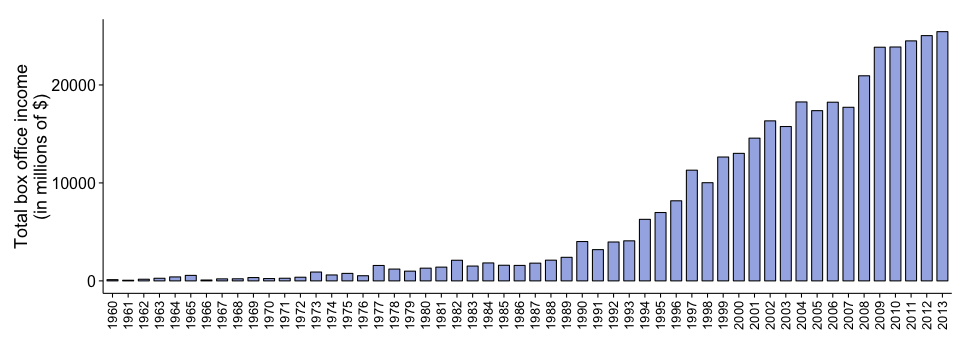

**Is it possible to leverage screenplay information to predict movie profitability and assist the descision-making process for screenplay selection?**

## Scope of the problem

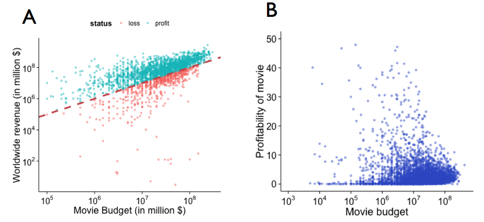

- A. There is a high linear relationship between movie budget and box office revenue.
- **B. It is a lot more interesting to predict the profitabilty of a movie.**

## The workflow of MillionDollar$tory

[figure not shown]

[MillionDollar$tory](http://statofmind.shinyapps.io/MillionDollarStory/)

## Predicting the profitability of a movie

- Some features that were tried but failed to produce convincing results: readability index, sentiment analysis, tf-idf, tf-idf with POS tagging.
- word2vec - Efficient Estimation of Word Representations in Vector Space (published by Google).
- Allows to cluster words with similar meaning. These clusters can be used as features in a predictive model.

\[ \hat{y} = x_{budget} + \sum_{i=1}^{n} x_{i, word2vec} \]

## Predicting the profitability of a movie

- Used 10-fold cross-validation to benchmark a variety of regression models for profitability prediction: linear regression (LR), MARS, SVM, Random Forest (RF), Generalized boosting (GBM) and CART.

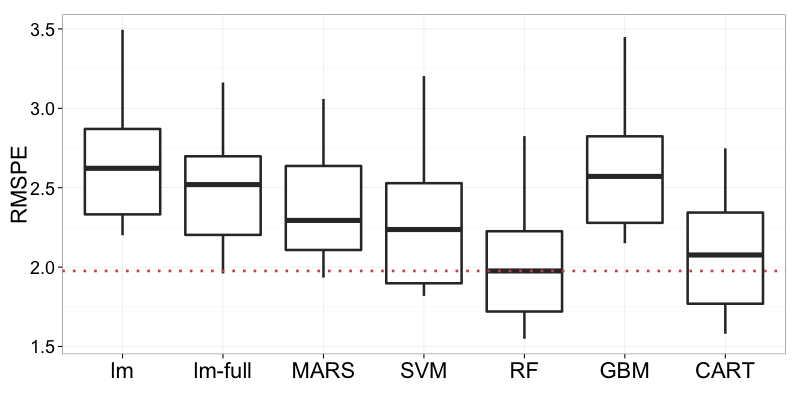

## About me: Thomas Vincent

[figure not shown]

## Movie analytics

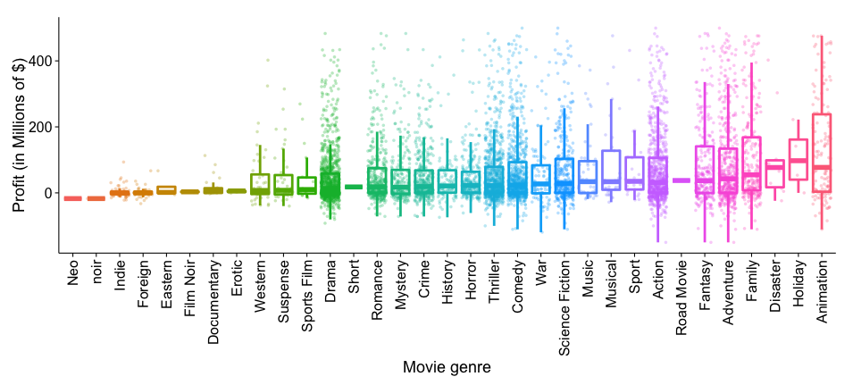

## Predicting the profitability of a movie

- Because we only use screenplay information, the main challenge is the identification, extraction and selection of features that may be available in movie scripts.
- Some features that were tried but failed to produce convincing results: readability index, sentiment analysis, tf-idf, tf-idf with POS tagging.
- word2vec - Efficient Estimation of Word Representations in Vector Space (published by Google).
- Allows to cluster words with similar meaning. These clusters can be used as features in a predictive model.

## Project Toolkit

[figure not shown]

## Movie analytics

- The data also offers the opportunity for some sentiment analysis of movie scripts.

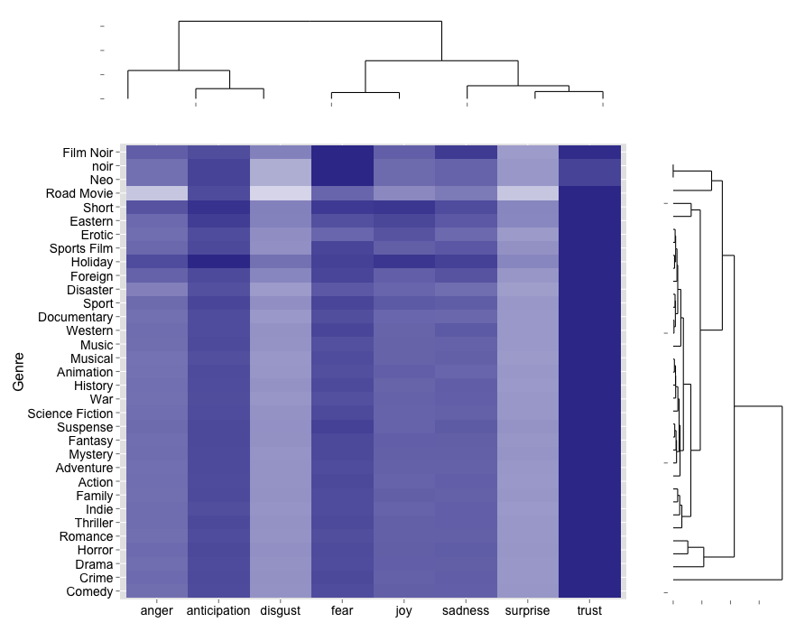

rmarkdown::render("MillionDollarStory_Presentation.Rmd")